# IE 582 Statistical Learning for Data Mining

## Homework 1

### Elvan Durdu 2021702186

```r
setwd("C:/Users/user/Desktop/all_ticks_wide.csv")
```

```r
dataw<-read.csv("all_ticks_wide.csv")
```

I choose to use wide format data.

## 1. Descriptive Analysis

The minimum, mean and maximum values of each stock can be seen from the following summary.

```r
summary(dataw)
```

```
                timestamp         AEFES             AKBNK
 2012-09-17T06:45:00Z:    1   Min.   : 0.0001   Min.   :0.0001
 2012-09-17T07:00:00Z:    1   1st Qu.:19.1605   1st Qu.:5.8500
 2012-09-17T07:15:00Z:    1   Median :20.6465   Median :6.3057
 2012-09-17T07:30:00Z:    1   Mean   :20.9822   Mean   :6.4731
 2012-09-17T07:45:00Z:    1   3rd Qu.:22.7320   3rd Qu.:6.9325
 2012-09-17T08:00:00Z:    1   Max.   :28.5090   Max.   :9.2124
 (Other)             :50006   NA's   :1881      NA's   :803
      AKSA             AKSEN           ALARK            ALBRK
 Min.   : 0.0001   Min.   :0.000   Min.   :0.0001   Min.   :1.026
 1st Qu.: 5.2088   1st Qu.:2.670   1st Qu.:1.5689   1st Qu.:1.225
 Median : 6.9853   Median :2.930   Median :1.9376   Median :1.360
 Mean   : 7.1275   Mean   :3.183   Mean   :2.0609   Mean   :1.365
 3rd Qu.: 8.7200   3rd Qu.:3.750   3rd Qu.:2.4214   3rd Qu.:1.500
 Max.   :15.1189   Max.   :5.190   Max.   :3.5143   Max.   :2.190
 NA's   :1418      NA's   :1841    NA's   :1677     NA's   :3150
     ANACM            ARCLK             ASELS             ASUZU
 Min.   :0.0001   Min.   : 0.0001   Min.   : 0.0001   Min.   : 0.0001
 1st Qu.:1.0470   1st Qu.:11.7111   1st Qu.: 4.9403   1st Qu.: 5.0748
 Median :1.2597   Median :15.0100   Median : 9.2757   Median : 5.9496
 Mean   :1.6721   Mean   :15.3881   Mean   :13.4325   Mean   : 6.4670
 3rd Qu.:2.4021   3rd Qu.:19.0877   3rd Qu.:22.7567   3rd Qu.: 7.1200
 Max.   :3.5021   Max.   :26.4278   Max.   :46.7616   Max.   :15.2800
 NA's   :1847     NA's   :967       NA's   :1209      NA's   :1579
     AYGAZ             BAGFS             BANVT            BRISA
 Min.   : 0.0001   Min.   : 0.0001   Min.   : 0.000   Min.   : 0.0001
 1st Qu.: 5.9515   1st Qu.: 8.2617   1st Qu.: 2.590   1st Qu.: 5.8900
 Median : 7.7238   Median :10.6100   Median : 3.710   Median : 6.7300
 Mean   : 8.1019   Mean   :10.4071   Mean   : 7.628   Mean   : 6.5449
 3rd Qu.:10.2690   3rd Qu.:12.3500   3rd Qu.:11.930   3rd Qu.: 7.3300
 Max.   :13.5935   Max.   :38.4352   Max.   :28.680   Max.   :10.3275
 NA's   :1893      NA's   :1362      NA's   :2061     NA's   :1075
     CCOLA             CEMAS           ECILC            EREGL
 Min.   : 0.0001   Min.   :0.000   Min.   :0.0001   Min.   : 0.0001
 1st Qu.:31.9782   1st Qu.:0.700   1st Qu.:1.1723   1st Qu.: 2.1812
 Median :34.8215   Median :0.870   Median :1.8214   Median : 3.0360
 Mean   :36.8907   Mean   :1.209   Mean   :2.0759   Mean   : 4.1795
 3rd Qu.:42.0497   3rd Qu.:1.500   3rd Qu.:2.7809   3rd Qu.: 6.7587
 Max.   :54.2208   Max.   :7.010   Max.   :4.2278   Max.   :10.4710
 NA's   :1263      NA's   :3618    NA's   :1520     NA's   :839
```

[output cut: 73 more lines]

```
 Min.   :0.0001   Min.   : 0.000   Min.   : 0.000   Min.   :0.0001
 1st Qu.:4.0322   1st Qu.: 4.020   1st Qu.: 0.389   1st Qu.:2.2682
 Median :4.4742   Median : 6.320   Median : 0.966   Median :2.6093
 Mean   :4.7354   Mean   : 5.943   Mean   : 2.434   Mean   :2.5663
 3rd Qu.:5.2460   3rd Qu.: 7.450   3rd Qu.: 4.230   3rd Qu.:2.8740
 Max.   :7.5814   Max.   :14.540   Max.   :10.675   Max.   :3.9581
 NA's   :800      NA's   :1231     NA's   :3957     NA's   :787
     YUNSA           ZOREN
 Min.   :0.000   Min.   :0.0001
 1st Qu.:3.007   1st Qu.:1.0338
 Median :4.108   Median :1.2500
 Mean   :4.080   Mean   :1.2481
 3rd Qu.:4.721   3rd Qu.:1.4265
 Max.   :9.527   Max.   :2.4430
 NA's   :4484    NA's   :1205
```

```r
library(ggplot2)
```

```r
library(zoo)
library(quantmod)
```

```r
dataw$timestamp <- as.POSIXct(dataw$timestamp, format="%Y-%m-%dT%H:%M:%SZ")
```

```r
dataw.xts <- xts(dataw[,2:61], order.by = dataw$timestamp)
```

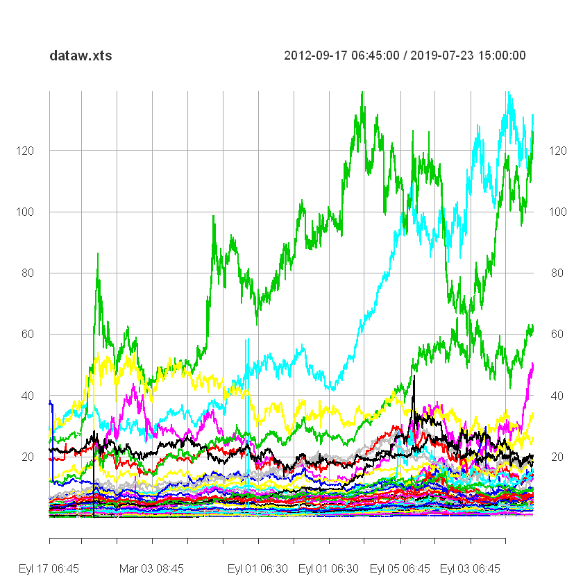

```r
plot(dataw.xts)
```

[figure not shown]

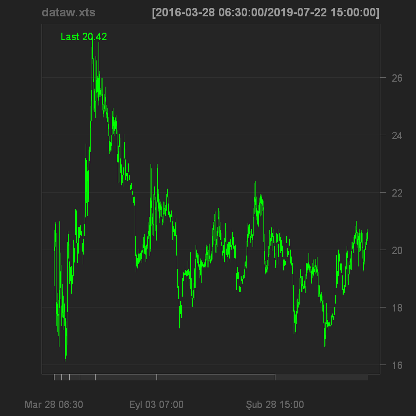

```r
chartSeries(dataw.xts)
```

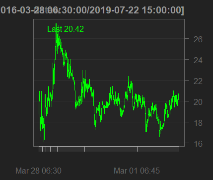

```r
str(dataw)
```

```
'data.frame':	50012 obs. of  61 variables:
 $ timestamp: POSIXct, format: "2012-09-17 06:45:00" "2012-09-17 07:00:00" ...
 $ AEFES    : num  22.4 22.4 22.4 22.4 22.6 ...
 $ AKBNK    : num  5.21 5.19 5.21 5.19 5.21 ...
 $ AKSA     : num  1.71 1.71 1.71 1.71 1.71 ...
 $ AKSEN    : num  3.87 3.86 NA 3.86 3.87 3.86 NA 3.86 NA 3.86 ...
 $ ALARK    : num  1.47 1.46 1.46 1.45 1.46 ...
 $ ALBRK    : num  1.14 1.13 1.14 1.13 1.14 ...
 $ ANACM    : num  1.06 1.06 1.07 1.07 1.07 ...
 $ ARCLK    : num  6.99 6.93 6.99 6.96 6.99 ...
 $ ASELS    : num  2.99 2.99 2.99 2.99 2.98 ...
 $ ASUZU    : num  2.5 2.51 2.48 2.49 2.49 ...
 $ AYGAZ    : num  3.54 3.55 3.55 3.54 3.54 ...
 $ BAGFS    : num  37.5 37.3 37.3 37.4 37.5 ...
 $ BANVT    : num  3.95 3.96 3.96 3.95 3.96 3.95 3.96 3.96 3.95 3.95 ...
```

[output cut: 47 more lines]

```r
head(dataw)
```

| timestamp | AEFES | AKBNK | AKSA | AKSEN | ALARK | ALBRK | ANACM | ARCLK | ASELS | ... | TTKOM | TUKAS | TUPRS | USAK | VAKBN | VESTL | YATAS | YKBNK | YUNSA | ZOREN |
| --- | --- | --- | --- | --- | --- | --- | --- | --- | --- | --- | --- | --- | --- | --- | --- | --- | --- | --- | --- | --- |
| 2012-09-17 06:45:00 | 22.3978 | 5.2084 | 1.7102 | 3.87 | 1.4683 | 1.1356 | 1.0634 | 6.9909 | 2.9948 | ... | 4.2639 | 0.96 | 29.8072 | 1.0382 | 3.8620 | 1.90 | 0.4172 | 2.5438 | 2.2619 | 0.7789 |
| 2012-09-17 07:00:00 | 22.3978 | 5.1938 | 1.7066 | 3.86 | 1.4574 | 1.1275 | 1.0634 | 6.9259 | 2.9948 | ... | 4.2521 | 0.96 | 29.7393 | 1.0382 | 3.8529 | 1.90 | 0.4229 | 2.5266 | 2.2462 | 0.7789 |
| 2012-09-17 07:15:00 | 22.3978 | 5.2084 | 1.7102 | NA | 1.4610 | 1.1356 | 1.0679 | 6.9909 | 2.9855 | ... | 4.2521 | 0.97 | 29.6716 | 1.0463 | 3.8436 | 1.91 | 0.4229 | 2.5266 | 2.2566 | 0.7789 |
| 2012-09-17 07:30:00 | 22.3978 | 5.1938 | 1.7102 | 3.86 | 1.4537 | 1.1275 | 1.0679 | 6.9584 | 2.9855 | ... | 4.2521 | 0.97 | 29.7393 | 1.0382 | 3.8529 | 1.91 | 0.4286 | 2.5324 | 2.2619 | 0.7860 |
| 2012-09-17 07:45:00 | 22.5649 | 5.2084 | 1.7102 | 3.87 | 1.4574 | 1.1356 | 1.0725 | 6.9909 | 2.9760 | ... | 4.2521 | 0.97 | 29.8072 | 1.0382 | 3.8620 | 1.90 | 0.4286 | 2.5324 | 2.2619 | 0.7789 |
| 2012-09-17 08:00:00 | 22.5649 | 5.2229 | 1.7102 | 3.86 | 1.4610 | 1.1275 | 1.0725 | 6.9584 | 2.9760 | ... | 4.2402 | NA | 29.8072 | 1.0382 | 3.8620 | 1.91 | 0.4314 | 2.5381 | 2.2566 | 0.7860 |

I checked the number of missing values in the data. It is seen that there many missing values for ISDMR. The reason for that it joined the Borsa Istanbul on March 2016. It can be excluded from the dataset for further analyses. Instead of excluding it from the data, I prefer to impute missing values.

```r
missing_count <- sapply(dataw.xts, function(x) sum(is.na(x)))
```

```r
missing_count
```

**AEFES**

1881

**AKBNK**

803

**AKSA**

1418

**AKSEN**

1841

**ALARK**

1677

**ALBRK**

3150

**ANACM**

1847

**ARCLK**

967

**ASELS**

1209

**ASUZU**

1579

**AYGAZ**

1893

**BAGFS**

1362

**BANVT**

2061

**BRISA**

1075

**CCOLA**

1263

**CEMAS**

3618

**ECILC**

1520

**EREGL**

839

**FROTO**

1017

**GARAN**

704

**GOODY**

1051

**GUBRF**

955

**HALKB**

941

**ICBCT**

5676

**ISCTR**

791

**ISDMR**

37785

**ISFIN**

7135

**ISYAT**

6828

**KAREL**

3980

**KARSN**

1485

**KCHOL**

919

**KRDMB**

2480

**KRDMD**

851

**MGROS**

1109

**OTKAR**

1227

**PARSN**

4687

**PETKM**

828

**PGSUS**

4791

**PRKME**

1546

**SAHOL**

917

**SASA**

2379

**SISE**

922

**SKBNK**

2742

**SODA**

1736

**TCELL**

869

**THYAO**

730

**TKFEN**

1082

**TOASO**

1066

**TRKCM**

1126

**TSKB**

1628

**TTKOM**

935

**TUKAS**

4083

**TUPRS**

869

**USAK**

2353

**VAKBN**

800

**VESTL**

1231

**YATAS**

3957

**YKBNK**

787

**YUNSA**

4484

**ZOREN**

1205

```r
install.packages("imputeTS")
```

[output not shown]

[output not shown]

[output not shown]

```r
library(imputeTS) # Since the installation of imputeTS package gives error, I provided the outputs of the following codes after running them on RStudio.
```

[output not shown]

Missing values are imputed by using linear interpolation.

```r
dataw.xts.imputed <- na_interpolation(dataw.xts, option = "linear")
```

[output not shown]

```r
dataw.xts.imputed.scaled<-scale(dataw.xts.imputed)
```

I also scaled the given data but it does not change the results. So, I did not use the scaled data for analyses.

```r
cor(dataw.xts.imputed)
```

[output not shown]

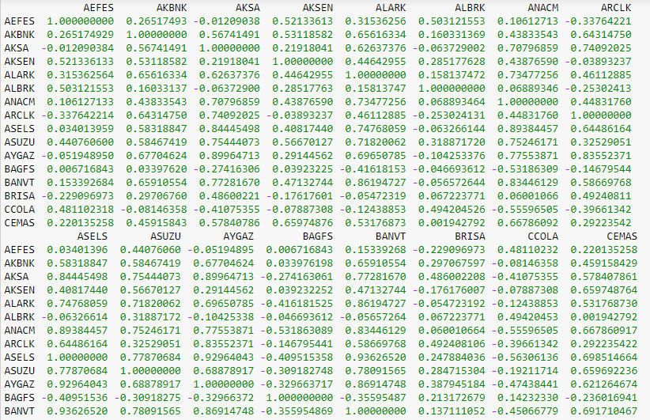

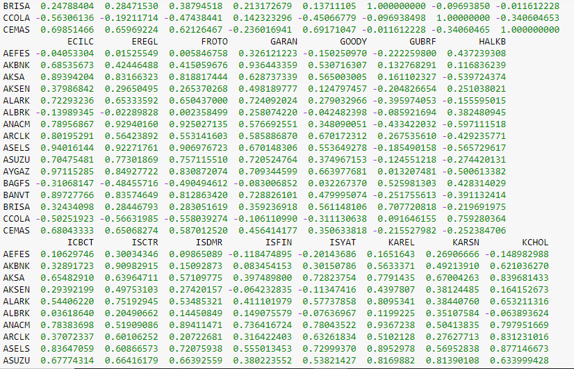

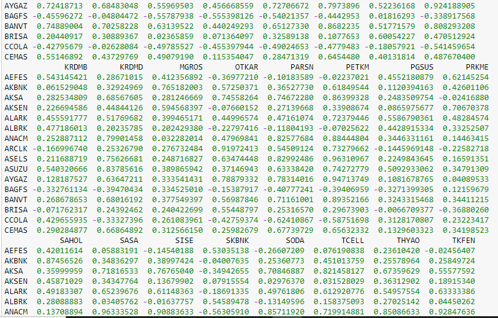

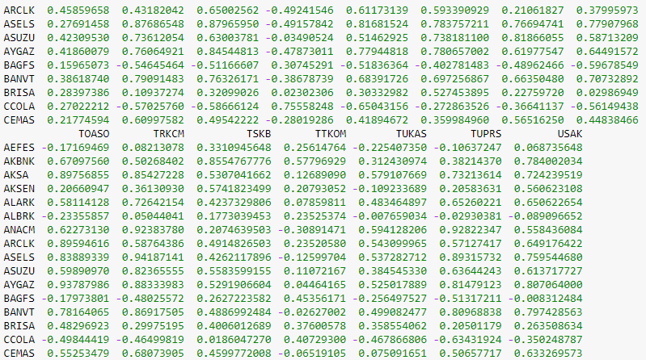

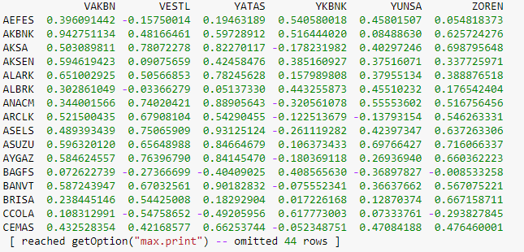

## 2. Moving Window Correlation

The 15 minute frequency data is converted into monthly stock prices in order to calculate correlation over a moving window.

```r
monthly_stock_prices <- to.period(dataw.xts.imputed, period = "months", OHLC = FALSE)
```

[output not shown]

The stock pairs that I have chosen are Akbank(AKBNK) and Garanti (GARAN).

```r
correlation <- cor(monthly_stock_prices$AKBNK, monthly_stock_prices$GARAN)
```

[output not shown]

```r
correlation
```

```
    GARAN
```

AKBNK 0.9446773

Then by using zoo library, I created a zoo object and calculated the 3 months moving window correlation between AKBNK and GARAN.

```r
monthly.stock.prices.zoo<-zoo(monthly_stock_prices[,c("AKBNK","GARAN")])
```

```r
rolling_correlation <- rollapply(monthly.stock.prices.zoo, width = 3, FUN = function(x) cor(x[,1], x[,2]), by.column = FALSE, align = "right") # 3 months moving correlation
rolling_correlation
```

[figure not shown]

[figure not shown]

[figure not shown]

[figure not shown]

[figure not shown]

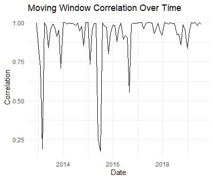

```r
correlation_data <- data.frame(
  Date = index(rolling_correlation),
  Correlation = coredata(rolling_correlation)  )
ggplot(correlation_data, aes(x = Date, y = Correlation)) +
  geom_line() +
  labs(title = "Moving Window Correlation Over Time", x = "Date", y = "Correlation") +
  theme_minimal()
```

Since the stocks AKBNK and GARAN operate in the same sector, it is expected that they often exhibit similar price movements. It is due to shared market conditions affecting this particular sector. Moving correlation values are mostly high and this is consistent with the expected situation. High correlation values mean that they show similar movements. As it is seen in the graph, the correlation value significantly drops from 1 , especially at 3 points. Besides these points, the correlation coefficient is quite close to 1.

## 3. Principal Component Analysis (PCA)

```r
stock_matrix <- as.matrix(dataw.xts.imputed)
library(FactoMineR)
```

```r
pca_result <- PCA(stock_matrix, graph = FALSE)
```

```r
summary(pca_result)
```

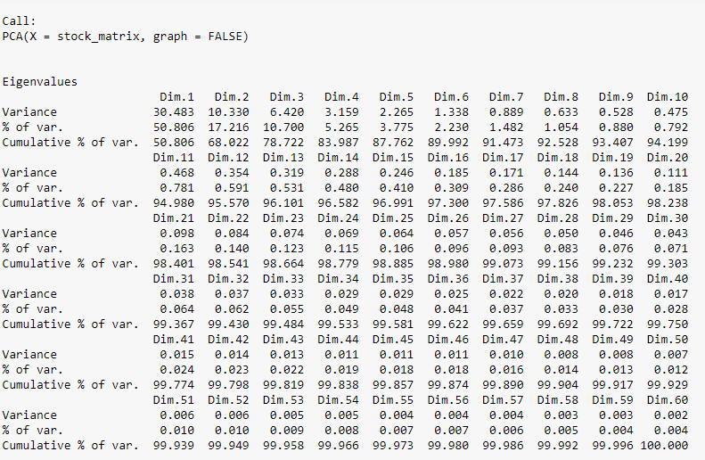

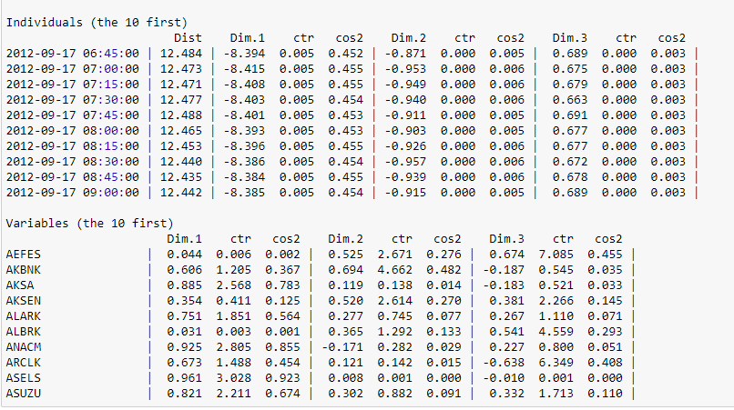

First 7 principal components can represent 91 % of the data. Moreover, first 4 principal components can represent 83 % of the data. First few components can be seen as latent variables depending on the aimed application.

```r
pca_result$var
```

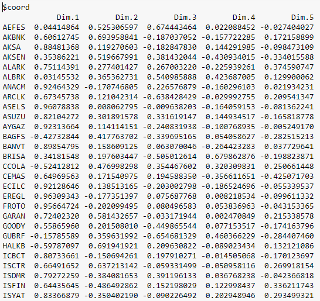

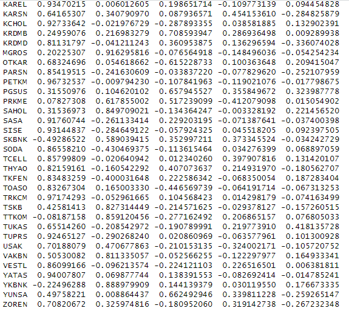

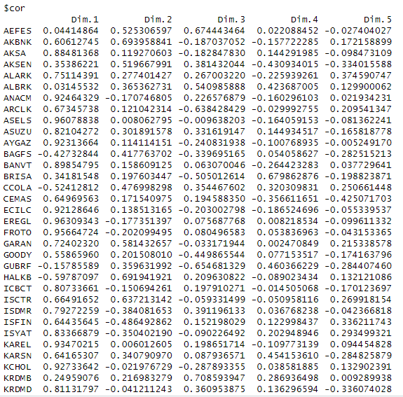

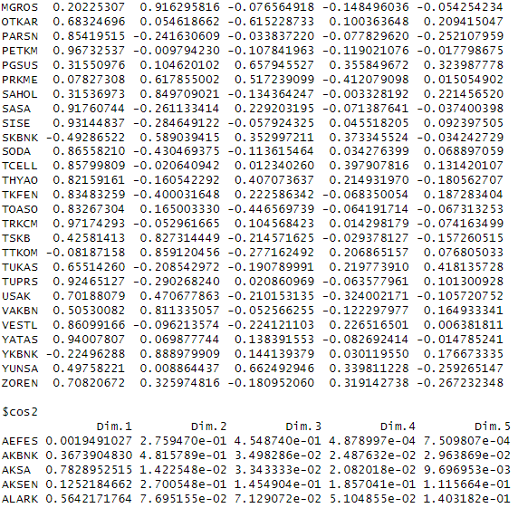

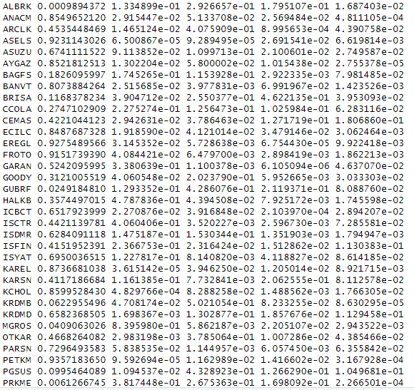

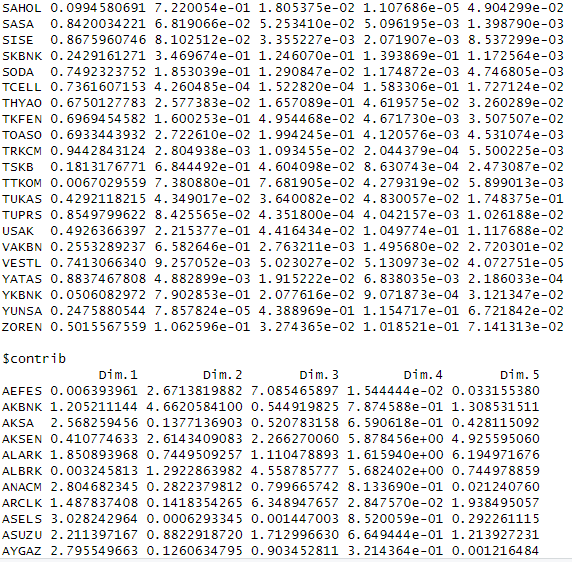

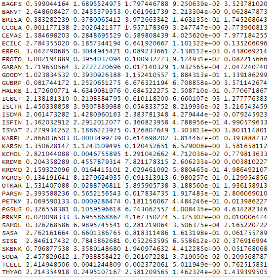

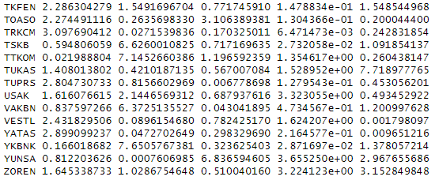

It is seen that TRKCM, PETKM, EREGL, FROTO, ASELS have higher contribution to first principal component.

```r
plot.PCA(pca_result)
```

[output not shown]

[figure not shown]

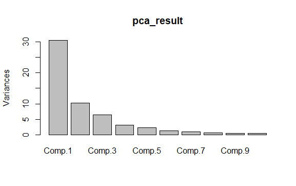

```r
pca_result <- princomp(stock_matrix, cor=T)
summary(pca_result, loadings=T)
plot(pca_result)
```

## 4. Inference with Google Trends

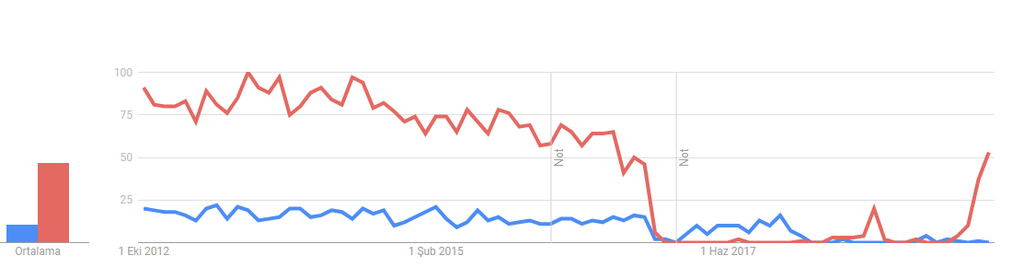

Red line shows IST:GARAN and blue line shows IST:AKBNK search volumes between 17.09.2012 and 23.07.2019. It seems to give consistent results with the moving correlation values.